# Nobel Prize Vizualization

Abigail Chen

##Research Goal

“The Nobel Prize is a set of annual international awards bestowed in several categories by Swedish and Norwegian institutions in recognition of academic, cultural, or scientific advances.” - Wikipedia.

The aim of this project is to create a nice visualization about Nobel Prize Winners and their different publications. This project will be using Rstudio. The Dataset can be found in **TidyTuesday’s Github**(https://github.com/rfordatascience/tidytuesday/tree/master/data/2019/2019-05-14). I hope you enjoy this. :)

##What is the Nobel Prize?

“On 27 November 1895, Alfred Nobel signed his last will and testament, giving the largest share of his fortune to a series of prizes in physics, chemistry, physiology or medicine, literature and peace – the Nobel Prizes. In 1968, Sveriges Riksbank (Sweden’s central bank) established The Sveriges Riksbank Prize in Economic Sciences in Memory of Alfred Nobel. Learn more about the Nobel Prize laureates here.” - NobelPrize.org. Alfred Nobel gave SEK 31 million of his own money, around SEK 1,7 billion now, for investments in “safe securities”, where the income will be distributed to the future winners. Nobel Prize is created for those with the greatest benefit to mankind.

For those worthy, the nobel prize bounty can be divided from two to three persons. The Nobel Prize started around 1901 up til now, my data set will be exploring the 1901 winners and their publications up til 2016. There will be some years when the Nobel Prizes were not awarded due to the World War I (1914-1918) and II (1939-1945), and the prizes here will be reserved for the future awards.

[figure not shown]

##Why are they called “Nobel Laureates”?

[figure not shown]

Nobel Laureate

Apparently, this stems from Greek Mythology, and a Greek god named Apollo. According to Wikipedia, Apollo is one of the most important and complex god in Greek mythology and he is recognized as a god of archery, music and dance, truth and prophecy, healing and diseases, the Sun and light, poetry, and more. Apollo wears a laurel wreath on his head, it’s made of leaves and branches of the bay laurel turned into a circular crown. In Ancient Greece, this laurel wreath is given and awarded to the champions and victors of the athletic and literary competitions.

##What will the Nobel Laureates receive once they are chosen?

[figure not shown]

Nobel Diploma

First they will get a Nobel Prize diploma, made especially for them. They will get unique artworks created by the best Swedish and Norweigian artists and calligraphers. All handmade and fully customized. Second they will get a Nobel Prize Medal handmade with 18 carat recycled gold. This medal has the portrait of Alfred Nobel, and his lifetime years. Third, they will be getting the Nobel Prize document indicating the amount they will get.

The aim of this project is to create a visualization about Nobel Prize Winners and their different publications. This project will be using RstudIO. The Dataset can be found in **TidyTuesday’s Github**(https://github.com/rfordatascience/tidytuesday/tree/master/data/2019/2019-05-14).

#Setting up the environment

##Libraries

```r
library(extrafont)
library(data.table)
library(tidytuesdayR)
library(lubridate)
library(ggplot2)
#library(hrbrthemes)
library(dplyr)
library(tidyverse)
library(scales)
library(readr)
library(igraph)
library(ggraph)
library(snakecase)
library(tm)
library(factoextra)
library(rpubs)
library(kableExtra)
library(gganimate)
library(tidytext)
library(viridis)
library(widyr)
library(tidygraph)
library(plotly)
library(modelsummary)
library(tidylo)
library(ggthemes)
```

##Loading the Data

##Exploring the data

Below is the list of the different variables, their class, and a short description found in the two data sets.

For the Nobel Prize Winners, there are 969 rows and 18 columns.

1. **prize_year**: (double) Year that Nobel Prize was awarded.
2. **category**: (character) Field of study/category.
3. **prize**: (character) Prize Name.
4. **motivation**: (character) Motivation of the award.
5. **prize_share**: (character) Share eg 1 of 1, 1 of 2, 1 of 4, etc.
6. **laureate_id**: (double) ID assigned to each winner.
7. **laureate_type**: (character) Individual or organization.
8. **full_name**: (character) Name of the winner.
9. **birth_date**: (double) Birth date of winner.
10. **birth_city**: (character) Birth city/state of winner.
11. **birth_country**: (character) Birth country of winner.
12. **gender**: (character) Binary gender of the winner.
13. **organization_name**: (character) Organization name.
14. **organization_city**: (character) Organization city.
15. **organization_country**: (character) Organization country.
16. **death_date**: (double) Death date of the winner (if dead).
17. **death_city**: (character) Death city (if dead).
18. **death_country**: (character) Death country (if dead)).

For the Nobel Prize Publications, there are 93,394 rows and 11 columns.

```r
count_rows_win <- count(nobel_winner_all_pubs)
count_cols_win <- ncol(nobel_winner_all_pubs)
```

19. **laureate_id**: (double) Assigned Laureate ID (doesn’t match other dataset).
20. **laureate_name**: (country) Abbreviated name.
21. **prize_year**: (double) Prize year.
22. **title**: (character) Title of paper.
23. **pub_year**: (double) Publication year.
24. **paper_id**: (double) Paper ID.
25. **doi**: (character) DOI of paper.
26. **journal**: (character) Journal paper published in.
27. **affiliation**: (character) Affiliation of the author.
28. **is_prize_winning_paper**: (character) Is associated as the Nobel winning paper (yes or no).
29. **category**: (character) Category/field of study.

##Defining the theme

```r
##Defining the theme

theme_nobel <- function(){
    font <- "Times New Roman"   #assign font family up front

    theme_wsj() %+replace%    #replace elements we want to change

    theme(

      legend.position = "top",            #legend position
      panel.background = element_blank(),  # panel background to NA
      panel.border = element_blank(),              # setting panel border

      #grid elements
      panel.grid.major = element_blank(),    #remove major gridlines
      panel.grid.minor = element_blank(),    #remove minor gridlines
      axis.ticks = element_blank(),          #remove axis ticks

      #plot elements
      plot.title = element_text(             #title
                   family = font,            #set font family
                   size = 12L,               #set font size
                   face = 'bold',            #bold typeface
                   hjust = 0.5,              #left align
                   vjust = 2),               #raise slightly

      plot.caption = element_text(           #caption
                   family = font,            #font family
                   size = 8,                 #font size
                   hjust = 0.5),             #right align

      #axis elements
      axis.text = element_text(              #axis text
                   family = font,            #axis famuly
                   size = 10),               #font size

      axis.title = element_text(             #axis titles
                   family = font,            #font family
                   size = 10),               #font size
    )
}
```

##Data Cleaning

To clean the data, I transformed the birth_date column to a year, month, day format. I also did the same for the death_date column. I also added the birth_year column from the birth_date. I used this to create the age column which is the difference of the prize_year and the birth_year.

```r
#Transforming to data.table
nobel_winners <- as.data.table(nobel_winners)
nobel_winner_all_pubs  <- as.data.table(nobel_winner_all_pubs)

#Transforming to date format
##For prize_year
#nobel_winners <- nobel_winners[, prize_year:= year(prize_year)]

#Adding birth year
nobel_winners  <- nobel_winners[, birth_year := year(birth_date)]

#For birth_date
nobel_winners <- nobel_winners[, birth_date := ymd(birth_date)]

#For death_date
nobel_winners <- nobel_winners[, death_date := ymd(death_date)]

#Creating the birth_year and age
nobel_winners$birth_year <- as.numeric(nobel_winners$birth_year)
nobel_winners$age <- nobel_winners$prize_year - nobel_winners$birth_year

#nobel_winners$birth_country = as.factor(nobel_winners$birth_country)
```

```r
# # creating new data table of countries to be used for further mapping
# countries <- nobel_winners[, .(count = .N), by = .(birth_country, prize_year)]
#
# # extracting each country and the year their content added to the Netflix
# countries <-  countries %>%
#   ungroup()%>%
#   separate_rows(birth_country,sep = ",")%>%
#   mutate(
#     birth_country=str_trim(birth_country)
#   )%>%
#   group_by(prize_year,birth_country)%>%
#   summarize(
#     count=n()
#   )%>%
#   ungroup()%>%
#   filter(birth_country!='NA',birth_country!="" )%>%
#   arrange(prize_year,desc(count))
#
#
# # Create function to drop null values
# row.has.na <- apply(countries, 1, function(x){any(is.na(x))})
# sum(row.has.na)
```

##Descriptive Summary

### Data summary for Categories

Nobel Prize Category Breakdown

| Category | N | Percent |
| --- | --- | --- |
| Chemistry | 194 | 20.02 |
| Economics | 83 | 8.57 |
| Literature | 113 | 11.66 |
| Medicine | 227 | 23.43 |
| Peace | 130 | 13.42 |
| Physics | 222 | 22.91 |

### Data summary for Prize Sharing

36% of the Nobel Prizes awarded went to individuals, while Pairs (34%), Trios (23%) and Groups of 4 (7%).

Laureate Prize Sharing Breakdown

| Prize Sharing | N | Percent |
| --- | --- | --- |
| 1/1 | 351 | 36.22 |
| 1/2 | 328 | 33.85 |
| 1/3 | 225 | 23.22 |
| 1/4 | 65 | 6.71 |

### Data summary for Laureate Type

97% of the Nobel Prizes awarded went to individuals, and the rest went to organizations.

Laureate Type Share Breakdown

| Laureate Type | N | Percent |
| --- | --- | --- |
| Individual | 939 | 96.90 |
| Organization | 30 | 3.10 |

### Data summary for Birth Country

29% of the Nobel Prizes awarded went to individuals born in the USA, followed by those from UK (9%).

Laureate Birth Country Breakdown

| Birth Country | N | Percent |
| --- | --- | --- |
| Argentina | 4 | 0.41 |
| Australia | 11 | 1.14 |
| Austria | 15 | 1.55 |
| Austria-Hungary (Austria) | 2 | 0.21 |
| Austria-Hungary (Bosnia and Herzegovina) | 1 | 0.10 |
| Austria-Hungary (Croatia) | 1 | 0.10 |
| Austria-Hungary (Czech Republic) | 4 | 0.41 |
| Austria-Hungary (Hungary) | 3 | 0.31 |
| Austria-Hungary (Poland) | 1 | 0.10 |
| Austria-Hungary (Slovenia) | 1 | 0.10 |
| Austria-Hungary (Ukraine) | 1 | 0.10 |
| Austrian Empire (Austria) | 2 | 0.21 |
| Austrian Empire (Czech Republic) | 1 | 0.10 |
| Austrian Empire (Italy) | 1 | 0.10 |
| Bavaria (Germany) | 1 | 0.10 |
| Belgium | 9 | 0.93 |
| Bosnia (Bosnia and Herzegovina) | 1 | 0.10 |
| Brazil | 1 | 0.10 |
| British India (Bangladesh) | 1 | 0.10 |
| British India (India) | 1 | 0.10 |
| British Mandate of Palestine (Israel) | 5 | 0.52 |
| British Protectorate of Palestine (Israel) | 1 | 0.10 |
| British West Indies (Saint Lucia) | 1 | 0.10 |
| Bulgaria | 1 | 0.10 |
| Burma (Myanmar) | 1 | 0.10 |
| Canada | 18 | 1.86 |
| Chile | 2 | 0.21 |
| China | 12 | 1.24 |
| Colombia | 2 | 0.21 |
| Costa Rica | 1 | 0.10 |

[output cut: 91 more lines]

### Data summary for Gender

92% of the Nobel Prizes awarded went to males, 5% to females and the rest to organizations.

Laureate Gender Share

| Gender | N | Percent |
| --- | --- | --- |
| Female | 50 | 5.16 |
| Male | 893 | 92.16 |

### Data summary for Laureate Publication Categories

42,600 Publications were published in the field of chemistry(46%), 29,200 for Medicine (31%), and 21,500 for Physics(23%).

Publication Category Distribution

| Category | N | Percent |
| --- | --- | --- |
| chemistry | 42657 | 45.67 |
| medicine | 29233 | 31.30 |
| physics | 21504 | 23.03 |

### Data summary for Laureate Age Upon Awarding

The youngest awardee is 17 years old, and oldest awardee is 90 years old. On average, the Nobel laureates are around 60 upon awarding.

Laureate Age Summary

|  | Min | Max | Mean | Median | N |
| --- | --- | --- | --- | --- | --- |
| Age | 17.00 | 90.00 | 59.48 | 60.00 | 938 |

##Distributions ### Distribution for Laureate Age Upon Awarding

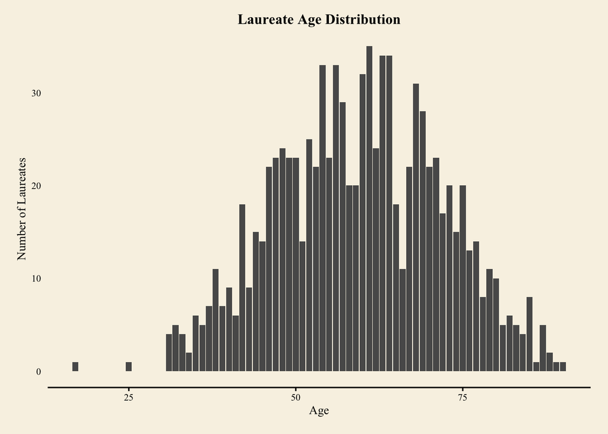

### Distribution for Categories

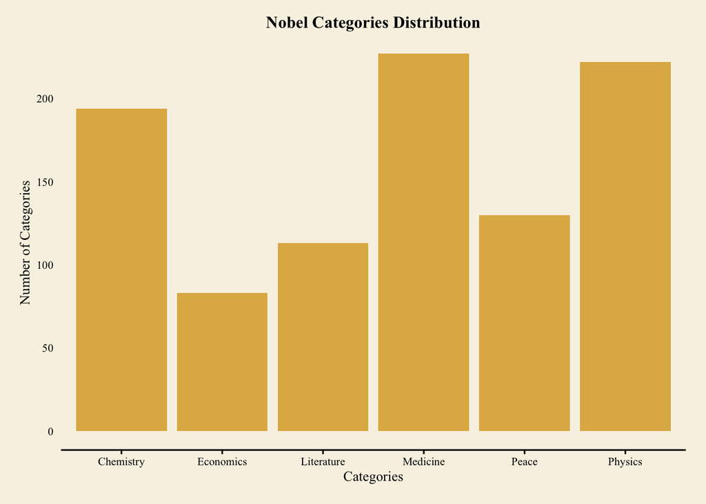

### Distribution for Prize Sharing

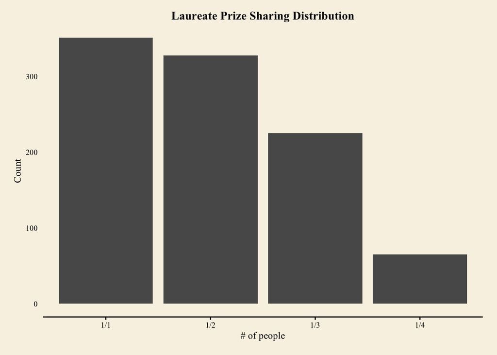

### Distribution for Laureate Type

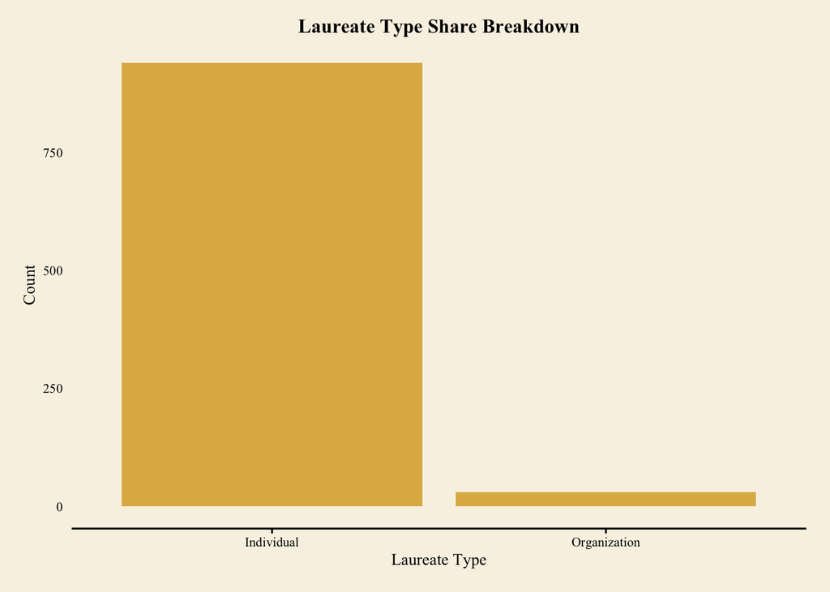

### Distribution for Laureate Gender

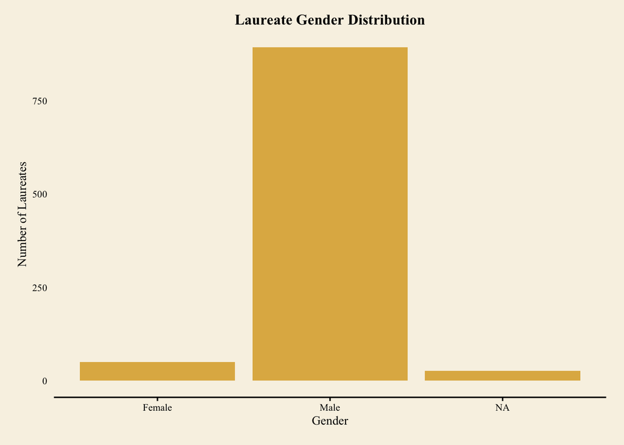

[figure not shown]

#How has the awarding of Nobel Price Changed since 1901 til now?

```r
#How has the awarding of Nobel Price Changed since 1901?
nobel_winners <- as.data.table(nobel_winners)

ggplot(nobel_winners[, .(count = .N), by = .(category, prize_year)], aes(x=prize_year, y=count, group = category, color=category)) +
  geom_line() +
  geom_point() +
  scale_color_viridis(discrete = TRUE) +
  ggtitle("Nobel Prize Per Year") +
  ylab("Number of Awards") +
  xlab("Prize") +
  labs(color = "Type", group = "Type") +
  theme(legend.position = "top", panel.background = element_rect(fill = NA),
        panel.border = element_blank(), axis.text=element_text(size=8),
        plot.title = element_text(size = 12L, face = "bold", hjust = 0.5) ) +
  transition_reveal(prize_year) +
  theme_nobel()+scale_colour_wsj("colors6")
```

[output not shown]

[output not shown]

In the below section, I will focusing on the main questions of this project.